# Part I - Prosper Loan Data Exploration

## by ( Chepngeno Millicent)

## Introduction

Loan is known to be the sum of money that a legal person borrows from another with cfondition that it be returned or repaid over time or at the later date and mostly it can be repaid with interest while prosper is to lend. loan services has expanded matching investors with needy borrowers in over 35 sites world-wide sometimes within 24 hours. Since 2005, when the first lending site was founded in the U.K.,the online platforms have provided billions of dollars worth of small loans to individuals and small businesses, with an expected $25bn-plus world-wide market by 2020 (Financial Times, 2014). Measurable data about loan applicants is limited, and loan lending platforms seek to expedite loan funding by facilitating the exchange of messages and images between borrowers and potential investors, who are most times from the same nation 2 . As any other business agreement, and especially because of its risky nature,peer-to-peer loan agreements can arguably constitute a good scenario where to study the impact of legal frameworks and cultural dimensions, both in terms of loan characteristics and how quickly the investor-borrower matching is accomplished. In ProperLoanData set I am to explore a sample of Prosper loan data to uncover What factors affect a loan’s outcome status,What affects the borrower’s APR or interest rate and if there are differences between loans depending on how large the original loan amount was.

## Preliminary Wrangling

```python
# import all packages and set plots to be embedded inline
import numpy as np
import pandas as pd
import matplotlib.pyplot as plt
import seaborn as sb

%matplotlib inline
import warnings
warnings.simplefilter("ignore")
```

```python
loan_data = pd.read_csv('prosperLoanData.csv')
```

```python
loan_data.head(10)
```

|  | ListingKey | ListingNumber | ListingCreationDate | CreditGrade | Term | LoanStatus | ClosedDate | BorrowerAPR | BorrowerRate | LenderYield | ... | LP_ServiceFees | LP_CollectionFees | LP_GrossPrincipalLoss | LP_NetPrincipalLoss | LP_NonPrincipalRecoverypayments | PercentFunded | Recommendations | InvestmentFromFriendsCount | InvestmentFromFriendsAmount | Investors |
| --- | --- | --- | --- | --- | --- | --- | --- | --- | --- | --- | --- | --- | --- | --- | --- | --- | --- | --- | --- | --- | --- |
| 0 | 1021339766868145413AB3B | 193129 | 2007-08-26 19:09:29.263000000 | C | 36 | Completed | 2009-08-14 00:00:00 | 0.16516 | 0.1580 | 0.1380 | ... | -133.18 | 0.0 | 0.0 | 0.0 | 0.0 | 1.0 | 0 | 0 | 0.0 | 258 |
| 1 | 10273602499503308B223C1 | 1209647 | 2014-02-27 08:28:07.900000000 | NaN | 36 | Current | NaN | 0.12016 | 0.0920 | 0.0820 | ... | 0.00 | 0.0 | 0.0 | 0.0 | 0.0 | 1.0 | 0 | 0 | 0.0 | 1 |
| 2 | 0EE9337825851032864889A | 81716 | 2007-01-05 15:00:47.090000000 | HR | 36 | Completed | 2009-12-17 00:00:00 | 0.28269 | 0.2750 | 0.2400 | ... | -24.20 | 0.0 | 0.0 | 0.0 | 0.0 | 1.0 | 0 | 0 | 0.0 | 41 |
| 3 | 0EF5356002482715299901A | 658116 | 2012-10-22 11:02:35.010000000 | NaN | 36 | Current | NaN | 0.12528 | 0.0974 | 0.0874 | ... | -108.01 | 0.0 | 0.0 | 0.0 | 0.0 | 1.0 | 0 | 0 | 0.0 | 158 |
| 4 | 0F023589499656230C5E3E2 | 909464 | 2013-09-14 18:38:39.097000000 | NaN | 36 | Current | NaN | 0.24614 | 0.2085 | 0.1985 | ... | -60.27 | 0.0 | 0.0 | 0.0 | 0.0 | 1.0 | 0 | 0 | 0.0 | 20 |
| 5 | 0F05359734824199381F61D | 1074836 | 2013-12-14 08:26:37.093000000 | NaN | 60 | Current | NaN | 0.15425 | 0.1314 | 0.1214 | ... | -25.33 | 0.0 | 0.0 | 0.0 | 0.0 | 1.0 | 0 | 0 | 0.0 | 1 |
| 6 | 0F0A3576754255009D63151 | 750899 | 2013-04-12 09:52:56.147000000 | NaN | 36 | Current | NaN | 0.31032 | 0.2712 | 0.2612 | ... | -22.95 | 0.0 | 0.0 | 0.0 | 0.0 | 1.0 | 0 | 0 | 0.0 | 1 |
| 7 | 0F1035772717087366F9EA7 | 768193 | 2013-05-05 06:49:27.493000000 | NaN | 36 | Current | NaN | 0.23939 | 0.2019 | 0.1919 | ... | -69.21 | 0.0 | 0.0 | 0.0 | 0.0 | 1.0 | 0 | 0 | 0.0 | 1 |
| 8 | 0F043596202561788EA13D5 | 1023355 | 2013-12-02 10:43:39.117000000 | NaN | 36 | Current | NaN | 0.07620 | 0.0629 | 0.0529 | ... | -16.77 | 0.0 | 0.0 | 0.0 | 0.0 | 1.0 | 0 | 0 | 0.0 | 1 |
| 9 | 0F043596202561788EA13D5 | 1023355 | 2013-12-02 10:43:39.117000000 | NaN | 36 | Current | NaN | 0.07620 | 0.0629 | 0.0529 | ... | -16.77 | 0.0 | 0.0 | 0.0 | 0.0 | 1.0 | 0 | 0 | 0.0 | 1 |

10 rows × 81 columns

```python
loan_data.info()
```

```
<class 'pandas.core.frame.DataFrame'>
RangeIndex: 113937 entries, 0 to 113936
Data columns (total 81 columns):
ListingKey                             113937 non-null object
ListingNumber                          113937 non-null int64
ListingCreationDate                    113937 non-null object
CreditGrade                            28953 non-null object
Term                                   113937 non-null int64
LoanStatus                             113937 non-null object
ClosedDate                             55089 non-null object
BorrowerAPR                            113912 non-null float64
BorrowerRate                           113937 non-null float64
LenderYield                            113937 non-null float64
EstimatedEffectiveYield                84853 non-null float64
EstimatedLoss                          84853 non-null float64
EstimatedReturn                        84853 non-null float64
ProsperRating (numeric)                84853 non-null float64
ProsperRating (Alpha)                  84853 non-null object
ProsperScore                           84853 non-null float64
ListingCategory (numeric)              113937 non-null int64
BorrowerState                          108422 non-null object
Occupation                             110349 non-null object
EmploymentStatus                       111682 non-null object
EmploymentStatusDuration               106312 non-null float64
IsBorrowerHomeowner                    113937 non-null bool
CurrentlyInGroup                       113937 non-null bool
GroupKey                               13341 non-null object
DateCreditPulled                       113937 non-null object
CreditScoreRangeLower                  113346 non-null float64
CreditScoreRangeUpper                  113346 non-null float64
FirstRecordedCreditLine                113240 non-null object
CurrentCreditLines                     106333 non-null float64
OpenCreditLines                        106333 non-null float64
TotalCreditLinespast7years             113240 non-null float64
OpenRevolvingAccounts                  113937 non-null int64
OpenRevolvingMonthlyPayment            113937 non-null float64
InquiriesLast6Months                   113240 non-null float64
TotalInquiries                         112778 non-null float64
CurrentDelinquencies                   113240 non-null float64
AmountDelinquent                       106315 non-null float64
```

[output cut: 31 more lines]

```
LP_CustomerPayments                    113937 non-null float64
LP_CustomerPrincipalPayments           113937 non-null float64
LP_InterestandFees                     113937 non-null float64
LP_ServiceFees                         113937 non-null float64
LP_CollectionFees                      113937 non-null float64
LP_GrossPrincipalLoss                  113937 non-null float64
LP_NetPrincipalLoss                    113937 non-null float64
LP_NonPrincipalRecoverypayments        113937 non-null float64
PercentFunded                          113937 non-null float64
Recommendations                        113937 non-null int64
InvestmentFromFriendsCount             113937 non-null int64
InvestmentFromFriendsAmount            113937 non-null float64
Investors                              113937 non-null int64
dtypes: bool(3), float64(50), int64(11), object(17)
memory usage: 68.1+ MB
```

```python
loan_data.shape
```

```
(113937, 81)
```

### Structure of the dataset.

This data set contains 113,937 loans with 81 variables on each loan, including loan amount, borrower rate (or interest rate), current loan status, borrower income, and many others.

### Main feature(s) of interest in the dataset.

Taking the questions I am to answer when exploring this data into consideration therefore thae main features i will use are : First question being ,What affects the borrower’s APR or interest rate?

> - LoanStatus
> - EmploymentStatus
> - StatedMonthlyIncome
> - IsBorrowerHomeowner
> - IncomeRange
> - StatedMonthlyIncome
> - BorrowerAPR
> - BorrowerState
> - ProsperRating (Alpha)

Second question being,What factors affect a loan’s outcome status?

> - LoanOriginalAmount
> - DebtToIncomeRatio
> - IncomeVerifiable
> - Term
> - ListingCreationDate
> - ListingCategory (numeric)

### Features in the dataset that support the investigation into the feature(s) of interest

**borrower's APR and the interest rate**.

## Assessment

```python
key_features = ['ListingCreationDate', 'ListingCategory (numeric)', 'BorrowerState', 'IsBorrowerHomeowner',
                'IncomeRange', 'IncomeVerifiable', 'DebtToIncomeRatio', 'StatedMonthlyIncome', 'Term', 'ProsperRating (Alpha)',
                'EmploymentStatus', 'LoanStatus', 'LoanOriginalAmount', 'BorrowerAPR']
```

```python
key_features
```

```
['ListingCreationDate',
 'ListingCategory (numeric)',
 'BorrowerState',
 'IsBorrowerHomeowner',
 'IncomeRange',
 'IncomeVerifiable',
 'DebtToIncomeRatio',
 'StatedMonthlyIncome',
 'Term',
 'ProsperRating (Alpha)',
 'EmploymentStatus',
 'LoanStatus',
 'LoanOriginalAmount',
 'BorrowerAPR']
```

```python
#acquiring data for the key_features
main_loandata = loan_data[key_features]
main_loandata
```

|  | ListingCreationDate | ListingCategory (numeric) | BorrowerState | IsBorrowerHomeowner | IncomeRange | IncomeVerifiable | DebtToIncomeRatio | StatedMonthlyIncome | Term | ProsperRating (Alpha) | EmploymentStatus | LoanStatus | LoanOriginalAmount | BorrowerAPR |
| --- | --- | --- | --- | --- | --- | --- | --- | --- | --- | --- | --- | --- | --- | --- |
| 0 | 2007-08-26 19:09:29.263000000 | 0 | CO | True | $25,000-49,999 | True | 0.17000 | 3083.333333 | 36 | NaN | Self-employed | Completed | 9425 | 0.16516 |
| 1 | 2014-02-27 08:28:07.900000000 | 2 | CO | False | $50,000-74,999 | True | 0.18000 | 6125.000000 | 36 | A | Employed | Current | 10000 | 0.12016 |
| 2 | 2007-01-05 15:00:47.090000000 | 0 | GA | False | Not displayed | True | 0.06000 | 2083.333333 | 36 | NaN | Not available | Completed | 3001 | 0.28269 |
| 3 | 2012-10-22 11:02:35.010000000 | 16 | GA | True | $25,000-49,999 | True | 0.15000 | 2875.000000 | 36 | A | Employed | Current | 10000 | 0.12528 |
| 4 | 2013-09-14 18:38:39.097000000 | 2 | MN | True | $100,000+ | True | 0.26000 | 9583.333333 | 36 | D | Employed | Current | 15000 | 0.24614 |
| 5 | 2013-12-14 08:26:37.093000000 | 1 | NM | True | $100,000+ | True | 0.36000 | 8333.333333 | 60 | B | Employed | Current | 15000 | 0.15425 |
| 6 | 2013-04-12 09:52:56.147000000 | 1 | KS | False | $25,000-49,999 | True | 0.27000 | 2083.333333 | 36 | E | Employed | Current | 3000 | 0.31032 |
| 7 | 2013-05-05 06:49:27.493000000 | 2 | CA | False | $25,000-49,999 | True | 0.24000 | 3355.750000 | 36 | C | Employed | Current | 10000 | 0.23939 |
| 8 | 2013-12-02 10:43:39.117000000 | 7 | IL | True | $25,000-49,999 | True | 0.25000 | 3333.333333 | 36 | AA | Employed | Current | 10000 | 0.07620 |
| 9 | 2013-12-02 10:43:39.117000000 | 7 | IL | True | $25,000-49,999 | True | 0.25000 | 3333.333333 | 36 | AA | Employed | Current | 10000 | 0.07620 |
| 10 | 2012-05-10 07:04:01.577000000 | 1 | MD | False | $75,000-99,999 | True | 0.12000 | 7500.000000 | 60 | C | Employed | Current | 13500 | 0.27462 |
| 11 | 2007-10-09 20:28:33.640000000 | 0 | NaN | False | $1-24,999 | True | 0.27000 | 1666.666667 | 36 | NaN | Full-time | Completed | 1000 | 0.15033 |
| 12 | 2013-12-15 20:01:10.757000000 | 1 | AL | False | $25,000-49,999 | True | 0.18000 | 2416.666667 | 36 | B | Employed | Past Due (1-15 days) | 4000 | 0.17969 |
| 13 | 2013-07-15 16:28:28.087000000 | 1 | AZ | True | $50,000-74,999 | True | 0.09000 | 5833.333333 | 36 | A | Employed | Current | 8500 | 0.13138 |
| 14 | 2013-04-19 11:17:41.700000000 | 1 | VA | False | $100,000+ | True | 0.20000 | 10833.333333 | 60 | A | Employed | Current | 19330 | 0.11695 |
| 15 | 2012-04-10 09:14:46.297000000 | 13 | FL | True | $50,000-74,999 | True | 0.49000 | 5500.000000 | 36 | HR | Other | Defaulted | 4000 | 0.35797 |
| 16 | 2013-07-16 12:42:48.680000000 | 6 | CA | True | $75,000-99,999 | True | 0.15000 | 8291.666667 | 60 | E | Full-time | Current | 4000 | 0.30748 |
| 17 | 2006-08-15 12:21:09.433000000 | 0 | NaN | True | Not displayed | True | 0.12000 | 5833.333333 | 36 | NaN | Not available | Chargedoff | 10000 | 0.13202 |
| 18 | 2013-02-20 03:48:37.470000000 | 1 | PA | False | $75,000-99,999 | True | 0.24000 | 6250.000000 | 36 | A | Employed | Current | 15000 | 0.12528 |
| 19 | 2013-08-21 06:49:02.093000000 | 1 | OR | False | $25,000-49,999 | True | 0.41000 | 3075.000000 | 60 | D | Employed | Current | 6500 | 0.24754 |
| 20 | 2013-11-22 11:35:02.987000000 | 1 | MN | True | $50,000-74,999 | True | 0.20000 | 5166.666667 | 36 | B | Employed | Current | 14000 | 0.16732 |
| 21 | 2007-11-30 20:33:49.227000000 | 0 | MI | False | $25,000-49,999 | True | 0.09000 | 3750.000000 | 36 | NaN | Full-time | Completed | 3000 | 0.21488 |
| 22 | 2013-01-30 09:36:13.783000000 | 1 | NY | False | $1-24,999 | True | 9.20000 | 118.333333 | 36 | HR | Other | Current | 4000 | 0.35356 |
| 23 | 2013-04-22 13:29:19.073000000 | 15 | IL | False | $25,000-49,999 | True | 0.39000 | 2500.000000 | 36 | D | Employed | Defaulted | 2000 | 0.28032 |
| 24 | 2013-12-03 11:34:46.127000000 | 1 | LA | True | $25,000-49,999 | True | 0.16000 | 2333.333333 | 36 | C | Employed | Current | 4000 | 0.19859 |
| 25 | 2013-10-02 14:31:09.157000000 | 15 | CA | False | $75,000-99,999 | True | 0.12000 | 6974.000000 | 36 | E | Employed | Current | 4000 | 0.30182 |
| 26 | 2013-02-12 18:07:31.690000000 | 1 | NY | False | $25,000-49,999 | True | 0.11000 | 3885.916667 | 60 | E | Employed | Completed | 4000 | 0.30748 |
| 27 | 2010-06-16 16:23:44.533000000 | 1 | CO | True | $75,000-99,999 | True | 0.26000 | 6666.666667 | 36 | A | Full-time | Completed | 4000 | 0.11296 |
| 28 | 2013-11-02 16:01:28.050000000 | 2 | PA | True | $25,000-49,999 | True | 0.12000 | 3600.000000 | 36 | C | Employed | Current | 10000 | 0.20268 |
| 29 | 2013-12-17 09:18:33.220000000 | 1 | LA | True | $100,000+ | True | 0.32000 | 10416.666667 | 36 | A | Employed | Current | 35000 | 0.15223 |
| ... | ... | ... | ... | ... | ... | ... | ... | ... | ... | ... | ... | ... | ... | ... |
| 113907 | 2013-11-09 06:55:05.690000000 | 1 | AZ | False | $25,000-49,999 | True | 0.40000 | 2166.666667 | 36 | HR | Employed | Current | 4000 | 0.35356 |
| 113908 | 2010-11-29 10:40:09.730000000 | 3 | NY | False | $25,000-49,999 | False | NaN | 2833.333333 | 36 | E | Employed | Completed | 7500 | 0.35858 |
| 113909 | 2012-09-08 10:34:38.837000000 | 2 | FL | True | $25,000-49,999 | True | 0.24000 | 3333.333333 | 60 | C | Employed | Current | 6000 | 0.27554 |
| 113910 | 2014-01-24 19:56:49.960000000 | 1 | TX | False | $100,000+ | True | 0.18000 | 18756.000000 | 36 | E | Employed | Current | 4000 | 0.32446 |
| 113911 | 2013-11-15 11:42:47.540000000 | 14 | MD | False | $25,000-49,999 | True | 0.29000 | 3333.333333 | 36 | D | Employed | Current | 10000 | 0.25330 |
| 113912 | 2013-12-16 16:36:00.990000000 | 2 | MN | False | $25,000-49,999 | True | 0.20000 | 2500.000000 | 36 | AA | Employed | Current | 4000 | 0.06726 |
| 113913 | 2010-04-25 15:13:27.963000000 | 1 | WA | True | $100,000+ | True | 0.25000 | 9750.000000 | 36 | A | Full-time | Completed | 8000 | 0.12410 |
| 113914 | 2006-08-09 14:34:40.010000000 | 0 | CA | False | Not displayed | True | 0.05000 | 2400.000000 | 36 | NaN | NaN | Defaulted | 3000 | 0.25757 |
| 113915 | 2008-07-29 05:22:29.390000000 | 7 | MA | True | $50,000-74,999 | True | 0.26000 | 4416.666667 | 36 | NaN | Full-time | Completed | 3000 | 0.22237 |
| 113916 | 2012-11-08 20:07:36.600000000 | 13 | FL | False | $50,000-74,999 | True | 0.15000 | 4583.333333 | 36 | E | Employed | Current | 4000 | 0.33286 |
| 113917 | 2013-11-23 04:52:50.057000000 | 1 | OH | False | $1-24,999 | True | 0.40000 | 1916.666667 | 36 | E | Employed | Current | 4000 | 0.32446 |
| 113918 | 2008-06-19 12:02:53.300000000 | 4 | CA | True | $50,000-74,999 | True | 0.39000 | 5583.333333 | 36 | NaN | Full-time | Defaulted | 7000 | 0.12201 |
| 113919 | 2013-05-07 18:49:59.750000000 | 2 | IL | True | $25,000-49,999 | True | 0.22000 | 2500.000000 | 36 | D | Other | Current | 4000 | 0.27285 |
| 113920 | 2013-06-11 05:49:40.247000000 | 1 | NJ | True | $50,000-74,999 | True | 0.25000 | 5208.333333 | 36 | HR | Employed | Current | 4000 | 0.35356 |
| 113921 | 2005-11-09 20:44:28.847000000 | 0 | NaN | False | Not displayed | True | 0.23284 | 12500.000000 | 36 | NaN | NaN | Completed | 1000 | NaN |
| 113922 | 2008-08-08 16:58:54.760000000 | 5 | GA | True | $50,000-74,999 | True | 0.18000 | 5250.000000 | 36 | NaN | Full-time | Completed | 5000 | 0.15094 |
| 113923 | 2008-09-10 08:26:30.537000000 | 1 | MS | True | $25,000-49,999 | True | 0.57000 | 3966.666667 | 36 | NaN | Full-time | Completed | 8000 | 0.22378 |
| 113924 | 2012-10-20 19:15:52.670000000 | 13 | WA | False | $25,000-49,999 | True | 0.17000 | 3208.333333 | 60 | A | Employed | Current | 5000 | 0.17317 |
| 113925 | 2013-04-25 13:54:45.017000000 | 1 | NY | False | $25,000-49,999 | True | 0.28000 | 2333.333333 | 36 | E | Employed | Current | 4000 | 0.31032 |
| 113926 | 2006-08-01 10:31:31.143000000 | 0 | CA | False | Not displayed | True | 0.07000 | 5416.666667 | 36 | NaN | Not available | Defaulted | 3000 | 0.29776 |
| 113927 | 2008-04-30 21:25:19.670000000 | 4 | WA | True | $100,000+ | True | 0.06000 | 10333.333333 | 36 | NaN | Full-time | Completed | 4292 | 0.07469 |
| 113928 | 2011-06-06 19:02:44.443000000 | 3 | CO | False | $25,000-49,999 | True | 0.27000 | 2333.333333 | 36 | C | Full-time | Completed | 2000 | 0.22362 |
| 113929 | 2013-07-06 17:40:01.657000000 | 2 | FL | False | $50,000-74,999 | True | 0.05000 | 4333.333333 | 36 | E | Employed | Completed | 2500 | 0.30285 |
| 113930 | 2013-07-08 10:24:49.700000000 | 1 | IN | True | $75,000-99,999 | True | 0.20000 | 6250.000000 | 36 | B | Employed | Current | 3000 | 0.20053 |
| 113931 | 2014-01-16 20:13:08.040000000 | 3 | IL | False | $75,000-99,999 | True | 0.28000 | 8146.666667 | 60 | B | Employed | Current | 25000 | 0.15016 |
| 113932 | 2013-04-14 05:55:02.663000000 | 1 | IL | True | $50,000-74,999 | True | 0.13000 | 4333.333333 | 36 | C | Employed | Current | 10000 | 0.22354 |
| 113933 | 2011-11-03 20:42:55.333000000 | 7 | PA | True | $75,000-99,999 | True | 0.11000 | 8041.666667 | 36 | A | Employed | FinalPaymentInProgress | 2000 | 0.13220 |
| 113934 | 2013-12-13 05:49:12.703000000 | 1 | TX | True | $25,000-49,999 | True | 0.51000 | 2875.000000 | 60 | D | Employed | Current | 10000 | 0.23984 |
| 113935 | 2011-11-14 13:18:26.597000000 | 2 | GA | True | $25,000-49,999 | True | 0.48000 | 3875.000000 | 60 | C | Full-time | Completed | 15000 | 0.28408 |
| 113936 | 2014-01-15 09:27:37.657000000 | 1 | NY | False | $50,000-74,999 | True | 0.23000 | 4583.333333 | 36 | A | Employed | Current | 2000 | 0.13189 |

113937 rows × 14 columns

```python
main_loandata.info()
```

```
<class 'pandas.core.frame.DataFrame'>
RangeIndex: 113937 entries, 0 to 113936
Data columns (total 14 columns):
ListingCreationDate          113937 non-null object
ListingCategory (numeric)    113937 non-null int64
BorrowerState                108422 non-null object
IsBorrowerHomeowner          113937 non-null bool
IncomeRange                  113937 non-null object
IncomeVerifiable             113937 non-null bool
DebtToIncomeRatio            105383 non-null float64
StatedMonthlyIncome          113937 non-null float64
Term                         113937 non-null int64
ProsperRating (Alpha)        84853 non-null object
EmploymentStatus             111682 non-null object
LoanStatus                   113937 non-null object
LoanOriginalAmount           113937 non-null int64
BorrowerAPR                  113912 non-null float64
dtypes: bool(2), float64(3), int64(3), object(6)
memory usage: 10.6+ MB
```

```python
#number of duplicates
sum(main_loandata.duplicated())
```

```
871
```

### assessments

1. There are 871 duplicates in the dataset
2. There are some mising values
3. ListingCreationDate is classified to be an object type instead of datetime type
4. BorrowerState,DebtToIncomeRatio and ProsperRating(Alpha) has some missing values
5. ProsperRating(Alpha) has ordinal variables

#### Data cleaning

```python
#removal of 871 duplicates in the dataset
main2_loandata = main_loandata.drop_duplicates()
main2_loandata
```

|  | ListingCreationDate | ListingCategory (numeric) | BorrowerState | IsBorrowerHomeowner | IncomeRange | IncomeVerifiable | DebtToIncomeRatio | StatedMonthlyIncome | Term | ProsperRating (Alpha) | EmploymentStatus | LoanStatus | LoanOriginalAmount | BorrowerAPR |
| --- | --- | --- | --- | --- | --- | --- | --- | --- | --- | --- | --- | --- | --- | --- |
| 0 | 2007-08-26 19:09:29.263000000 | 0 | CO | True | $25,000-49,999 | True | 0.17000 | 3083.333333 | 36 | NaN | Self-employed | Completed | 9425 | 0.16516 |
| 1 | 2014-02-27 08:28:07.900000000 | 2 | CO | False | $50,000-74,999 | True | 0.18000 | 6125.000000 | 36 | A | Employed | Current | 10000 | 0.12016 |
| 2 | 2007-01-05 15:00:47.090000000 | 0 | GA | False | Not displayed | True | 0.06000 | 2083.333333 | 36 | NaN | Not available | Completed | 3001 | 0.28269 |
| 3 | 2012-10-22 11:02:35.010000000 | 16 | GA | True | $25,000-49,999 | True | 0.15000 | 2875.000000 | 36 | A | Employed | Current | 10000 | 0.12528 |
| 4 | 2013-09-14 18:38:39.097000000 | 2 | MN | True | $100,000+ | True | 0.26000 | 9583.333333 | 36 | D | Employed | Current | 15000 | 0.24614 |
| 5 | 2013-12-14 08:26:37.093000000 | 1 | NM | True | $100,000+ | True | 0.36000 | 8333.333333 | 60 | B | Employed | Current | 15000 | 0.15425 |
| 6 | 2013-04-12 09:52:56.147000000 | 1 | KS | False | $25,000-49,999 | True | 0.27000 | 2083.333333 | 36 | E | Employed | Current | 3000 | 0.31032 |
| 7 | 2013-05-05 06:49:27.493000000 | 2 | CA | False | $25,000-49,999 | True | 0.24000 | 3355.750000 | 36 | C | Employed | Current | 10000 | 0.23939 |
| 8 | 2013-12-02 10:43:39.117000000 | 7 | IL | True | $25,000-49,999 | True | 0.25000 | 3333.333333 | 36 | AA | Employed | Current | 10000 | 0.07620 |
| 10 | 2012-05-10 07:04:01.577000000 | 1 | MD | False | $75,000-99,999 | True | 0.12000 | 7500.000000 | 60 | C | Employed | Current | 13500 | 0.27462 |
| 11 | 2007-10-09 20:28:33.640000000 | 0 | NaN | False | $1-24,999 | True | 0.27000 | 1666.666667 | 36 | NaN | Full-time | Completed | 1000 | 0.15033 |
| 12 | 2013-12-15 20:01:10.757000000 | 1 | AL | False | $25,000-49,999 | True | 0.18000 | 2416.666667 | 36 | B | Employed | Past Due (1-15 days) | 4000 | 0.17969 |
| 13 | 2013-07-15 16:28:28.087000000 | 1 | AZ | True | $50,000-74,999 | True | 0.09000 | 5833.333333 | 36 | A | Employed | Current | 8500 | 0.13138 |
| 14 | 2013-04-19 11:17:41.700000000 | 1 | VA | False | $100,000+ | True | 0.20000 | 10833.333333 | 60 | A | Employed | Current | 19330 | 0.11695 |
| 15 | 2012-04-10 09:14:46.297000000 | 13 | FL | True | $50,000-74,999 | True | 0.49000 | 5500.000000 | 36 | HR | Other | Defaulted | 4000 | 0.35797 |
| 16 | 2013-07-16 12:42:48.680000000 | 6 | CA | True | $75,000-99,999 | True | 0.15000 | 8291.666667 | 60 | E | Full-time | Current | 4000 | 0.30748 |
| 17 | 2006-08-15 12:21:09.433000000 | 0 | NaN | True | Not displayed | True | 0.12000 | 5833.333333 | 36 | NaN | Not available | Chargedoff | 10000 | 0.13202 |
| 18 | 2013-02-20 03:48:37.470000000 | 1 | PA | False | $75,000-99,999 | True | 0.24000 | 6250.000000 | 36 | A | Employed | Current | 15000 | 0.12528 |
| 19 | 2013-08-21 06:49:02.093000000 | 1 | OR | False | $25,000-49,999 | True | 0.41000 | 3075.000000 | 60 | D | Employed | Current | 6500 | 0.24754 |
| 20 | 2013-11-22 11:35:02.987000000 | 1 | MN | True | $50,000-74,999 | True | 0.20000 | 5166.666667 | 36 | B | Employed | Current | 14000 | 0.16732 |
| 21 | 2007-11-30 20:33:49.227000000 | 0 | MI | False | $25,000-49,999 | True | 0.09000 | 3750.000000 | 36 | NaN | Full-time | Completed | 3000 | 0.21488 |
| 22 | 2013-01-30 09:36:13.783000000 | 1 | NY | False | $1-24,999 | True | 9.20000 | 118.333333 | 36 | HR | Other | Current | 4000 | 0.35356 |
| 23 | 2013-04-22 13:29:19.073000000 | 15 | IL | False | $25,000-49,999 | True | 0.39000 | 2500.000000 | 36 | D | Employed | Defaulted | 2000 | 0.28032 |
| 24 | 2013-12-03 11:34:46.127000000 | 1 | LA | True | $25,000-49,999 | True | 0.16000 | 2333.333333 | 36 | C | Employed | Current | 4000 | 0.19859 |
| 25 | 2013-10-02 14:31:09.157000000 | 15 | CA | False | $75,000-99,999 | True | 0.12000 | 6974.000000 | 36 | E | Employed | Current | 4000 | 0.30182 |
| 26 | 2013-02-12 18:07:31.690000000 | 1 | NY | False | $25,000-49,999 | True | 0.11000 | 3885.916667 | 60 | E | Employed | Completed | 4000 | 0.30748 |
| 27 | 2010-06-16 16:23:44.533000000 | 1 | CO | True | $75,000-99,999 | True | 0.26000 | 6666.666667 | 36 | A | Full-time | Completed | 4000 | 0.11296 |
| 28 | 2013-11-02 16:01:28.050000000 | 2 | PA | True | $25,000-49,999 | True | 0.12000 | 3600.000000 | 36 | C | Employed | Current | 10000 | 0.20268 |
| 29 | 2013-12-17 09:18:33.220000000 | 1 | LA | True | $100,000+ | True | 0.32000 | 10416.666667 | 36 | A | Employed | Current | 35000 | 0.15223 |
| 30 | 2012-01-30 17:59:17.200000000 | 20 | CA | False | $25,000-49,999 | True | 0.11000 | 3750.000000 | 36 | A | Employed | Completed | 10000 | 0.12782 |
| ... | ... | ... | ... | ... | ... | ... | ... | ... | ... | ... | ... | ... | ... | ... |
| 113907 | 2013-11-09 06:55:05.690000000 | 1 | AZ | False | $25,000-49,999 | True | 0.40000 | 2166.666667 | 36 | HR | Employed | Current | 4000 | 0.35356 |
| 113908 | 2010-11-29 10:40:09.730000000 | 3 | NY | False | $25,000-49,999 | False | NaN | 2833.333333 | 36 | E | Employed | Completed | 7500 | 0.35858 |
| 113909 | 2012-09-08 10:34:38.837000000 | 2 | FL | True | $25,000-49,999 | True | 0.24000 | 3333.333333 | 60 | C | Employed | Current | 6000 | 0.27554 |
| 113910 | 2014-01-24 19:56:49.960000000 | 1 | TX | False | $100,000+ | True | 0.18000 | 18756.000000 | 36 | E | Employed | Current | 4000 | 0.32446 |
| 113911 | 2013-11-15 11:42:47.540000000 | 14 | MD | False | $25,000-49,999 | True | 0.29000 | 3333.333333 | 36 | D | Employed | Current | 10000 | 0.25330 |
| 113912 | 2013-12-16 16:36:00.990000000 | 2 | MN | False | $25,000-49,999 | True | 0.20000 | 2500.000000 | 36 | AA | Employed | Current | 4000 | 0.06726 |
| 113913 | 2010-04-25 15:13:27.963000000 | 1 | WA | True | $100,000+ | True | 0.25000 | 9750.000000 | 36 | A | Full-time | Completed | 8000 | 0.12410 |
| 113914 | 2006-08-09 14:34:40.010000000 | 0 | CA | False | Not displayed | True | 0.05000 | 2400.000000 | 36 | NaN | NaN | Defaulted | 3000 | 0.25757 |
| 113915 | 2008-07-29 05:22:29.390000000 | 7 | MA | True | $50,000-74,999 | True | 0.26000 | 4416.666667 | 36 | NaN | Full-time | Completed | 3000 | 0.22237 |
| 113916 | 2012-11-08 20:07:36.600000000 | 13 | FL | False | $50,000-74,999 | True | 0.15000 | 4583.333333 | 36 | E | Employed | Current | 4000 | 0.33286 |
| 113917 | 2013-11-23 04:52:50.057000000 | 1 | OH | False | $1-24,999 | True | 0.40000 | 1916.666667 | 36 | E | Employed | Current | 4000 | 0.32446 |
| 113918 | 2008-06-19 12:02:53.300000000 | 4 | CA | True | $50,000-74,999 | True | 0.39000 | 5583.333333 | 36 | NaN | Full-time | Defaulted | 7000 | 0.12201 |
| 113919 | 2013-05-07 18:49:59.750000000 | 2 | IL | True | $25,000-49,999 | True | 0.22000 | 2500.000000 | 36 | D | Other | Current | 4000 | 0.27285 |
| 113920 | 2013-06-11 05:49:40.247000000 | 1 | NJ | True | $50,000-74,999 | True | 0.25000 | 5208.333333 | 36 | HR | Employed | Current | 4000 | 0.35356 |
| 113921 | 2005-11-09 20:44:28.847000000 | 0 | NaN | False | Not displayed | True | 0.23284 | 12500.000000 | 36 | NaN | NaN | Completed | 1000 | NaN |
| 113922 | 2008-08-08 16:58:54.760000000 | 5 | GA | True | $50,000-74,999 | True | 0.18000 | 5250.000000 | 36 | NaN | Full-time | Completed | 5000 | 0.15094 |
| 113923 | 2008-09-10 08:26:30.537000000 | 1 | MS | True | $25,000-49,999 | True | 0.57000 | 3966.666667 | 36 | NaN | Full-time | Completed | 8000 | 0.22378 |
| 113924 | 2012-10-20 19:15:52.670000000 | 13 | WA | False | $25,000-49,999 | True | 0.17000 | 3208.333333 | 60 | A | Employed | Current | 5000 | 0.17317 |
| 113925 | 2013-04-25 13:54:45.017000000 | 1 | NY | False | $25,000-49,999 | True | 0.28000 | 2333.333333 | 36 | E | Employed | Current | 4000 | 0.31032 |
| 113926 | 2006-08-01 10:31:31.143000000 | 0 | CA | False | Not displayed | True | 0.07000 | 5416.666667 | 36 | NaN | Not available | Defaulted | 3000 | 0.29776 |
| 113927 | 2008-04-30 21:25:19.670000000 | 4 | WA | True | $100,000+ | True | 0.06000 | 10333.333333 | 36 | NaN | Full-time | Completed | 4292 | 0.07469 |
| 113928 | 2011-06-06 19:02:44.443000000 | 3 | CO | False | $25,000-49,999 | True | 0.27000 | 2333.333333 | 36 | C | Full-time | Completed | 2000 | 0.22362 |
| 113929 | 2013-07-06 17:40:01.657000000 | 2 | FL | False | $50,000-74,999 | True | 0.05000 | 4333.333333 | 36 | E | Employed | Completed | 2500 | 0.30285 |
| 113930 | 2013-07-08 10:24:49.700000000 | 1 | IN | True | $75,000-99,999 | True | 0.20000 | 6250.000000 | 36 | B | Employed | Current | 3000 | 0.20053 |
| 113931 | 2014-01-16 20:13:08.040000000 | 3 | IL | False | $75,000-99,999 | True | 0.28000 | 8146.666667 | 60 | B | Employed | Current | 25000 | 0.15016 |
| 113932 | 2013-04-14 05:55:02.663000000 | 1 | IL | True | $50,000-74,999 | True | 0.13000 | 4333.333333 | 36 | C | Employed | Current | 10000 | 0.22354 |
| 113933 | 2011-11-03 20:42:55.333000000 | 7 | PA | True | $75,000-99,999 | True | 0.11000 | 8041.666667 | 36 | A | Employed | FinalPaymentInProgress | 2000 | 0.13220 |
| 113934 | 2013-12-13 05:49:12.703000000 | 1 | TX | True | $25,000-49,999 | True | 0.51000 | 2875.000000 | 60 | D | Employed | Current | 10000 | 0.23984 |
| 113935 | 2011-11-14 13:18:26.597000000 | 2 | GA | True | $25,000-49,999 | True | 0.48000 | 3875.000000 | 60 | C | Full-time | Completed | 15000 | 0.28408 |
| 113936 | 2014-01-15 09:27:37.657000000 | 1 | NY | False | $50,000-74,999 | True | 0.23000 | 4583.333333 | 36 | A | Employed | Current | 2000 | 0.13189 |

113066 rows × 14 columns

```python
sum(main2_loandata.duplicated())
```

```
0
```

```python
main2_loandata.info()
```

```
<class 'pandas.core.frame.DataFrame'>
Int64Index: 113066 entries, 0 to 113936
Data columns (total 14 columns):
ListingCreationDate          113066 non-null object
ListingCategory (numeric)    113066 non-null int64
BorrowerState                107551 non-null object
IsBorrowerHomeowner          113066 non-null bool
IncomeRange                  113066 non-null object
IncomeVerifiable             113066 non-null bool
DebtToIncomeRatio            104594 non-null float64
StatedMonthlyIncome          113066 non-null float64
Term                         113066 non-null int64
ProsperRating (Alpha)        83982 non-null object
EmploymentStatus             110811 non-null object
LoanStatus                   113066 non-null object
LoanOriginalAmount           113066 non-null int64
BorrowerAPR                  113041 non-null float64
dtypes: bool(2), float64(3), int64(3), object(6)
memory usage: 11.4+ MB
```

```python
# The mising values ,
missing_values = ['BorrowerState','DebtToIncomeRatio','ProsperRating (Alpha)','BorrowerAPR']
missing_values
```

```
['BorrowerState', 'DebtToIncomeRatio', 'ProsperRating (Alpha)', 'BorrowerAPR']
```

```python
#dropping of the missing values
main2_loandata.dropna(inplace=True)
```

```python
main2_loandata.info()
```

```
<class 'pandas.core.frame.DataFrame'>
Int64Index: 76768 entries, 1 to 113936
Data columns (total 14 columns):
ListingCreationDate          76768 non-null object
ListingCategory (numeric)    76768 non-null int64
BorrowerState                76768 non-null object
IsBorrowerHomeowner          76768 non-null bool
IncomeRange                  76768 non-null object
IncomeVerifiable             76768 non-null bool
DebtToIncomeRatio            76768 non-null float64
StatedMonthlyIncome          76768 non-null float64
Term                         76768 non-null int64
ProsperRating (Alpha)        76768 non-null object
EmploymentStatus             76768 non-null object
LoanStatus                   76768 non-null object
LoanOriginalAmount           76768 non-null int64
BorrowerAPR                  76768 non-null float64
dtypes: bool(2), float64(3), int64(3), object(6)
memory usage: 7.8+ MB
```

```python
#ListingCreationDate is classified to be an object type instead of datetime type
import datetime
```

```python
main2_loandata['ListingCreationDate'] = pd.to_datetime(main2_loandata['ListingCreationDate'])
```

```python
main2_loandata.info()
```

```
<class 'pandas.core.frame.DataFrame'>
Int64Index: 76768 entries, 1 to 113936
Data columns (total 14 columns):
ListingCreationDate          76768 non-null datetime64[ns]
ListingCategory (numeric)    76768 non-null int64
BorrowerState                76768 non-null object
IsBorrowerHomeowner          76768 non-null bool
IncomeRange                  76768 non-null object
IncomeVerifiable             76768 non-null bool
DebtToIncomeRatio            76768 non-null float64
StatedMonthlyIncome          76768 non-null float64
Term                         76768 non-null int64
ProsperRating (Alpha)        76768 non-null object
EmploymentStatus             76768 non-null object
LoanStatus                   76768 non-null object
LoanOriginalAmount           76768 non-null int64
BorrowerAPR                  76768 non-null float64
dtypes: bool(2), datetime64[ns](1), float64(3), int64(3), object(5)
memory usage: 7.8+ MB
```

```python
 #Convertinng prosperRating (Alpha) into ordered categorical
ordinal_info = {'ProsperRating (Alpha)': ['HR', 'E', 'D', 'C', 'B', 'AA', 'A']}

for var in ordinal_info:
    ordinal2_info = pd.api.types.CategoricalDtype(ordered = True,
                                                categories = ordinal_info[var])
    main2_loandata[var] = main2_loandata[var].astype(ordinal2_info)
```

```python
print(main2_loandata[var].head())
print(main2_loandata[var].tail())
```

```
1    A
3    A
4    D
5    B
6    E
Name: ProsperRating (Alpha), dtype: category
Categories (7, object): [HR < E < D < C < B < AA < A]
113932    C
113933    A
113934    D
113935    C
113936    A
Name: ProsperRating (Alpha), dtype: category
Categories (7, object): [HR < E < D < C < B < AA < A]
```

```python
main2_loandata.corr()
```

|  | ListingCategory (numeric) | IsBorrowerHomeowner | IncomeVerifiable | DebtToIncomeRatio | StatedMonthlyIncome | Term | LoanOriginalAmount | BorrowerAPR |
| --- | --- | --- | --- | --- | --- | --- | --- | --- |
| ListingCategory (numeric) | 1.000000 | -0.071716 | 0.007012 | -0.041088 | -0.020699 | -0.065307 | -0.204240 | 0.104146 |
| IsBorrowerHomeowner | -0.071716 | 1.000000 | 0.004245 | -0.013112 | 0.181795 | 0.074828 | 0.172749 | -0.126121 |
| IncomeVerifiable | 0.007012 | 0.004245 | 1.000000 | -0.020704 | -0.002617 | 0.000430 | 0.004685 | -0.004149 |
| DebtToIncomeRatio | -0.041088 | -0.013112 | -0.020704 | 1.000000 | -0.140476 | -0.000125 | -0.017957 | 0.128858 |
| StatedMonthlyIncome | -0.020699 | 0.181795 | -0.002617 | -0.140476 | 1.000000 | 0.019593 | 0.299582 | -0.156880 |
| Term | -0.065307 | 0.074828 | 0.000430 | -0.000125 | 0.019593 | 1.000000 | 0.338900 | -0.056782 |
| LoanOriginalAmount | -0.204240 | 0.172749 | 0.004685 | -0.017957 | 0.299582 | 0.338900 | 1.000000 | -0.418336 |
| BorrowerAPR | 0.104146 | -0.126121 | -0.004149 | 0.128858 | -0.156880 | -0.056782 | -0.418336 | 1.000000 |

```python
main2_loandata.describe()
```

|  | ListingCategory (numeric) | DebtToIncomeRatio | StatedMonthlyIncome | Term | LoanOriginalAmount | BorrowerAPR |
| --- | --- | --- | --- | --- | --- | --- |
| count | 76768.000000 | 76768.000000 | 76768.000000 | 76768.000000 | 76768.000000 | 76768.000000 |
| mean | 3.293143 | 0.258692 | 5964.256138 | 42.701230 | 9248.961416 | 0.223978 |
| std | 4.389691 | 0.319727 | 5089.682309 | 11.710835 | 6389.782292 | 0.079291 |
| min | 0.000000 | 0.000000 | 0.250000 | 12.000000 | 1000.000000 | 0.045830 |
| 25% | 1.000000 | 0.150000 | 3528.895834 | 36.000000 | 4000.000000 | 0.162590 |
| 50% | 1.000000 | 0.220000 | 5000.000000 | 36.000000 | 8000.000000 | 0.215660 |
| 75% | 3.000000 | 0.320000 | 7166.666667 | 60.000000 | 14000.000000 | 0.287800 |
| max | 20.000000 | 10.010000 | 483333.333333 | 60.000000 | 35000.000000 | 0.423950 |

## Univariate Exploration

From the first question that i need to answer that is factors affecting the borrowers APR and the second question which is rfactors affecting tha loan outcome status.Taking into consideration the questions the interest rate plays a major role in that if you the interest rate wiil apply to the borrower according majorly with the amount of money borrowed while the loan outcome status is determined by if there was a high charge of interest there ill be a low outcome.Therefore i will the APR as the main feature in the dataset.

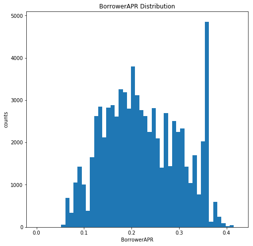

```python
bins = np.linspace(0, main2_loandata.BorrowerAPR.max(),50)
plt.figure(figsize=(8,8))
plt.hist(data=main2_loandata,x='BorrowerAPR',bins=bins)
plt.xlabel('BorrowerAPR')
plt.ylabel('counts')
plt.title('BorrowerAPR Distribution');
```

[figure not shown]

```python
main2_loandata['BorrowerAPR'].value_counts().plot(kind='pie',figsize=(12,12))
```

### what to note:

Concerning the question on the loan outcome status the term given to the borrower by the prosper can determine the outcome of the loan.

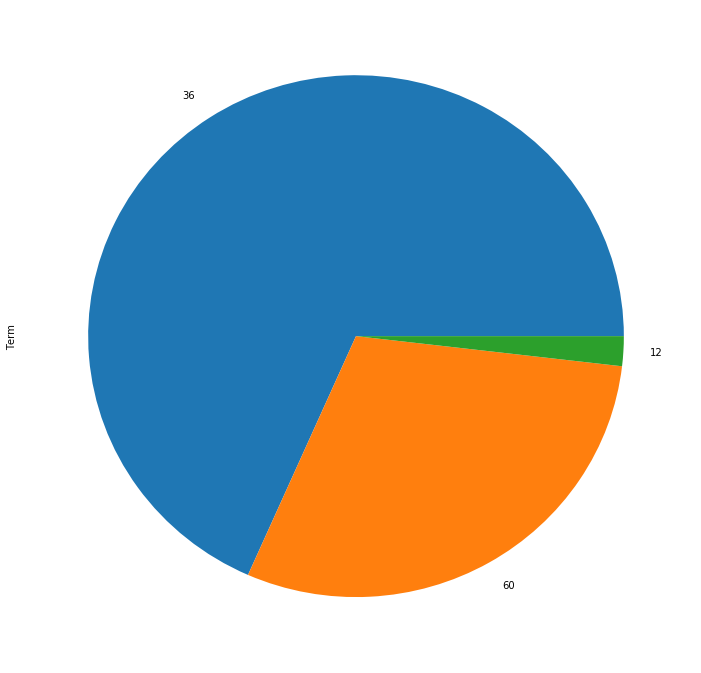

```python
main2_loandata['Term'].value_counts().plot(kind='pie',figsize=(12,12))
```

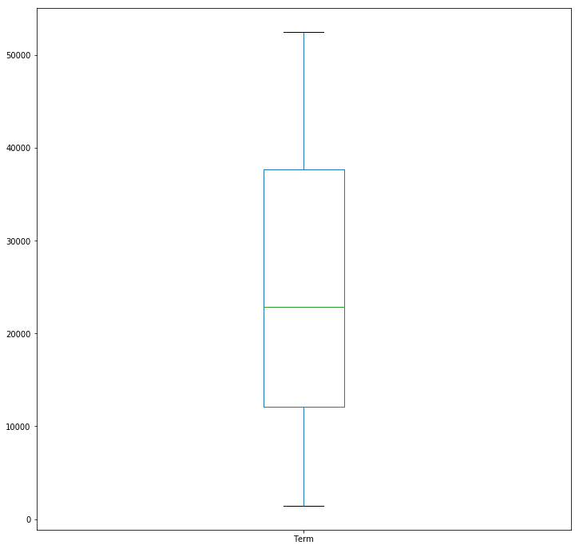

```python
main2_loandata['Term'].value_counts().plot(kind='box',figsize=(12,12),sharey=False)
```

### What to note:

There amount of term given to the borrowers by the prosper shows to have a high variability from the box plot and having most of the borrowers prefer having a term of **36 months** thatis from the pie chart and this will have an influence on the final loan outcome.

Other feature that can affect the borrowers loans outcome is the borrowers income

[figure not shown]

```python
plt.figure(figsize=(12,6))
# Transform the income value to log scale and the x axis to logarithmic sacle then plot the graph
bins_max = np.log10(main2_loandata.StatedMonthlyIncome.max())
plt.xscale('log')
bins = 10**np.linspace(0, bins_max, 100)
plt.hist(data=main2_loandata, x='StatedMonthlyIncome', bins=bins)
plt.xticks([3e2, 1e3, 3e3, 1e4, 3e4, 1e5],['1000$', '3000$', '10000$', '30000$', '100000$']);
plt.xlabel('Stated Monthly Income')
plt.ylabel('counts')
plt.title('statedmonthlyincome distribution');
```

### what to note:

#### How the prosper rating is located to the borrower

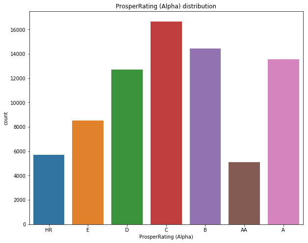

```python
plt.figure(figsize=(10,8))
sb.countplot(data=main2_loandata,x='ProsperRating (Alpha)').set(title="ProsperRating (Alpha) distribution");
```

### what to note:

The list that the prosper rating (Alpha) **C category** has most counts but category **AA** has least counts compared to other categories.This shows that list of category c was most preffered.

## Bivariate Exploration

> Investigation between pairs of different variables from the univariate exploration(StatedMonthlyIncome,Term,BorrowerAPR,LoanOriginalAmount and ProsperRating(Alpha).

```python
columns_study=['StatedMonthlyIncome','Term','BorrowerAPR','LoanOriginalAmount']
columns_study
```

```
['StatedMonthlyIncome', 'Term', 'BorrowerAPR', 'LoanOriginalAmount']
```

```python
#collection of data of the features used in theunivariate exploration
bivariate_loandata=main2_loandata[columns_study]
bivariate_loandata.head(10)
```

|  | StatedMonthlyIncome | Term | BorrowerAPR | LoanOriginalAmount |
| --- | --- | --- | --- | --- |
| 1 | 6125.000000 | 36 | 0.12016 | 10000 |
| 3 | 2875.000000 | 36 | 0.12528 | 10000 |
| 4 | 9583.333333 | 36 | 0.24614 | 15000 |
| 5 | 8333.333333 | 60 | 0.15425 | 15000 |
| 6 | 2083.333333 | 36 | 0.31032 | 3000 |
| 7 | 3355.750000 | 36 | 0.23939 | 10000 |
| 8 | 3333.333333 | 36 | 0.07620 | 10000 |
| 10 | 7500.000000 | 60 | 0.27462 | 13500 |
| 12 | 2416.666667 | 36 | 0.17969 | 4000 |
| 13 | 5833.333333 | 36 | 0.13138 | 8500 |

```python
correlation=bivariate_loandata.corr()
correlation
```

|  | StatedMonthlyIncome | Term | BorrowerAPR | LoanOriginalAmount |
| --- | --- | --- | --- | --- |
| StatedMonthlyIncome | 1.000000 | 0.019593 | -0.156880 | 0.299582 |
| Term | 0.019593 | 1.000000 | -0.056782 | 0.338900 |
| BorrowerAPR | -0.156880 | -0.056782 | 1.000000 | -0.418336 |
| LoanOriginalAmount | 0.299582 | 0.338900 | -0.418336 | 1.000000 |

```python
bivariate_loandata.shape
```

```
(76768, 4)
```

```python
bivariate_sample = bivariate_loandata.sample(n=500,replace=False)
bivariate_sample.shape
```

```
(500, 4)
```

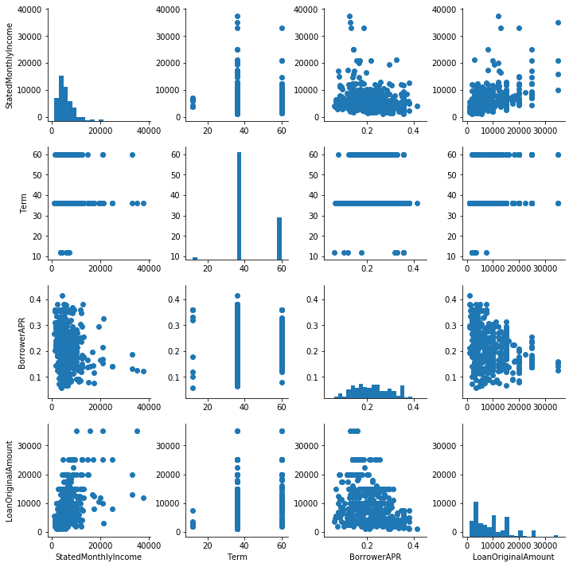

```python
plot=sb.PairGrid(data=bivariate_sample,vars = columns_study)
plot.map_offdiag(plt.scatter)
plot.map_diag(plt.hist,bins=20)
```

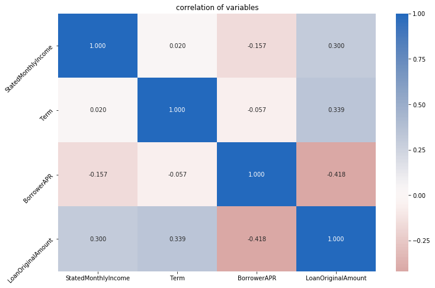

```python
plt.figure(figsize=(12,8))
sb.heatmap(data=correlation, annot = True, fmt = '.3f',
           cmap = 'vlag_r', center = 0).set(title="correlation of variables")
plt.yticks(rotation = 45)
plt.show()
```

### What to note:

From the pairgrid graph ,having histograms from the diagonal and the scatter plots from of the diagonals ,there is no clear relaionship between the variables.Afer plotting the heat there is clear correlationship between he variables.

> . There is a **positive correlationship between the term and the statedmonthlyloan** ,showing that the higher the statedmonthlyamount the higher the longer the term the borrower will receive due to he borrower having a chance of borrowing large amount of loan and repaiying it after a longer term in installments.

> .There is a **negative corelationship between the term and the borrowerAPR** ,the longer the term the borrower receives the the lower the borrowerAPR due to he payment of the interest rate in installments .

> .There is a **positive corelationship between the loanoriginalamount and the statedmonthlyincome**,the higher the statedmonthlyincome the higher he loanoriginalamount due to high probablity of clearing the loan afer a given term

> .There is a **negative corelationship between the the borrowersAPR and statedmonthlyincome**,the higher the statedmonthlyincome of the borrower the the lower the borrersAPR.

> . There is a **positive corellationship between the term and the loanoriginalamount**,the longer the term the higher the original amount o ensure clearence of the loan balance.

> . There is a **negative corelationship between the loanoriginaamount and the borrowerAPR**,looking into the ratio of the loanoriginalamount and the borrowerAPR annually the higher the loan the lower the borrowerAPR

##### relationship between the term and originalloanamount

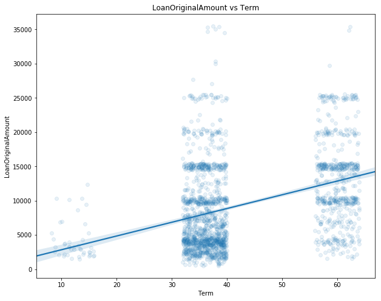

```python
plt.figure(figsize=(10, 8))
sb.regplot(data=main2_loandata.sample(2000, random_state=1), x='Term', y='LoanOriginalAmount',
            x_jitter=4,y_jitter=500,scatter_kws={'alpha': 0.1}).set(title="LoanOriginalAmount vs Term");
```

### What to note:

It has a positive linear relationship ,an increase in the originalamount leads to an increase in term. we can also see that borrowers whose loanaoriginal amount ranges between 2500 and 15000 inclusive shows to prefer a term of 30-40months.

### Other nteresting relationship between the other features (not the main feature(s) of interest)

#### what is the relationship between the loanoriginalamount and the employment status of the borrowers.

```
[Text(0.5,1,'Employmentstatus distribution')]
```

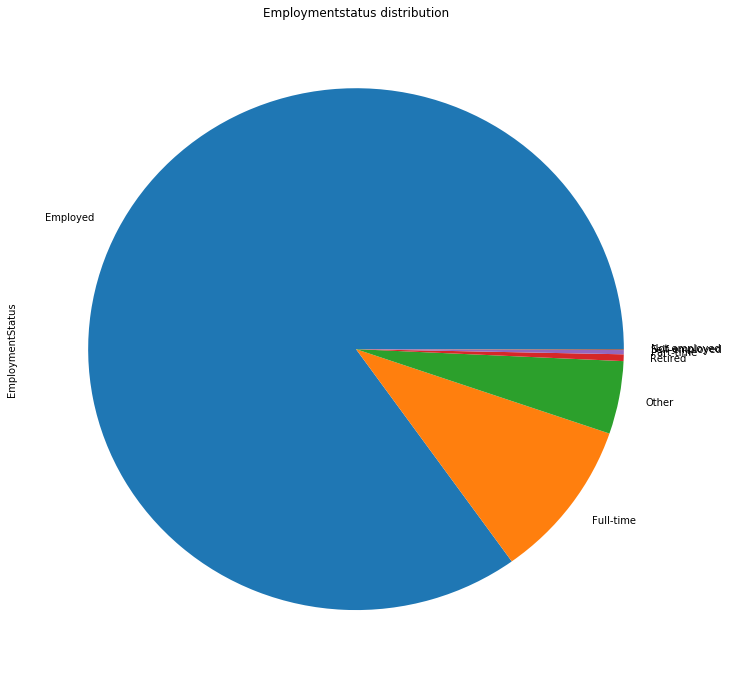

```python
# the propotion of the employment status
main2_loandata['EmploymentStatus'].value_counts().plot(kind='pie',figsize=(12,12)).set(title="Employmentstatus distribution")
```

```
[Text(0.5,1,'LoanOriginalAmount vs EmploymentStatus')]
```

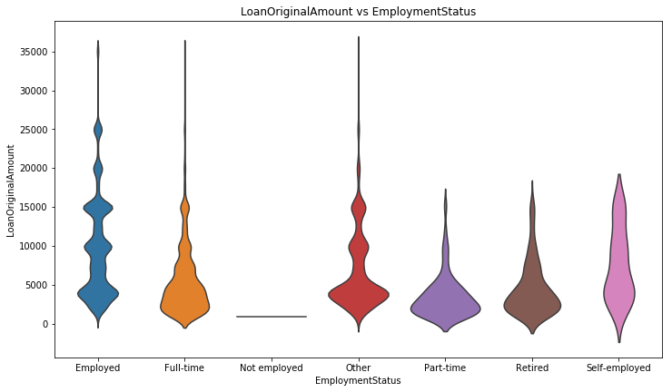

```python
plt.figure(figsize=(12, 15))
plt.subplot(2,1,1)
sb.violinplot(data=main2_loandata.sort_values(by='EmploymentStatus'), x='EmploymentStatus', y='LoanOriginalAmount', inner=None).set(title="LoanOriginalAmount vs EmploymentStatus")
```

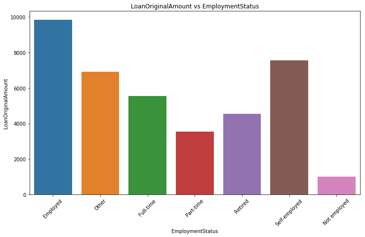

```python
plt.figure(figsize=(12,15))
plt.subplot(2,1,2)
sb.barplot(data=main2_loandata, x='EmploymentStatus', y='LoanOriginalAmount', ci=None).set(title="LoanOriginalAmount vs EmploymentStatus")
plt.xticks(rotation= 45);
```

### What to note:

> .The proportion of the employrd is the highest

> .From the vio0lin plot we not that though the employed has the highest number in the loan borrowers we find that the most of the employed acquire loan below 15000 dollars.

> .From the violin plot we note that there is relationship between employment status and the loanoriginalamount whereby from the employment status we find that most of the borrowers prefer to borrowers money less than 10000 dollars .

> . From the histograms barcharts the employed have the highest loanoriginalamount compared to other employment status while not employed has the least loanaoriganlamount and where the maximum being below 2000 dollars

### Key Takeaways from Bivariate Exploration

1. positive corellationship between the term and the loanoriginalamount
2. positive corelationship between the loanoriginalamount and the statedmonthlyincome
3. positive correlationship between the term and the statedmonthlyloan
4. negative corelationship between the the borrowersAPR and statedmonthlyincome
5. negative corelationship between the loanoriginaamount and the borrowerAPR
6. negative corelationship between the term and the borrowerAPR
7. employed have the highest loanoriginalamount compared to other employment status while not employed has the least loanaoriganlamount

### Multivariate Exploration

The relationship between more than two variables.

### A relationship between the loan originalamount,the borrowersAPR and the income range

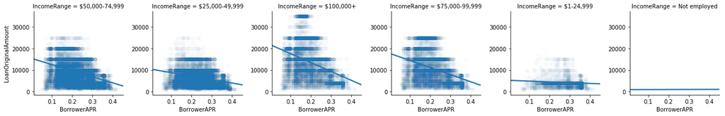

```python
plt.figure(figsize=(8,15))
plot = sb.FacetGrid(data=main2_loandata, col='IncomeRange')
plot.map(sb.regplot, 'BorrowerAPR','LoanOriginalAmount', scatter_kws={'alpha': 0.01});
```

### What to note:

> . From the grid above the higher the loanoriginalamount the lower the borrowerAPR

> .An increase in income range leads to an an increase in the loanoriginalamount and enjoys a low borrowersAPR

> As the income range decreases the borrowersAPR tends to be constant as well as the loanoriginalamount

### A relationship between the loan originalamount,the Term and the ProsperRating (Alpha)

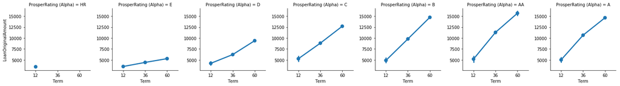

```python
plot = sb.FacetGrid(data=main2_loandata, col='ProsperRating (Alpha)')
plot.map(sb.pointplot, 'Term','LoanOriginalAmount', order=None);
```

### What to note:

> generally as the the loan originalamount increases the term increases

## Conclusions

**income range -** An increase in income range leads to an an increase in the loanoriginalamount

**Term -** an increase in term leads to an increase in the loanoriginalamount

**BorrowersAPR-** an increase in the borrowersAPR leads to decrease in the loanoriginaamount

#### 2 factors that affect the borrowersAPR

**income range -** An increase in income range leads to an an increase in the loanoriginalamount and enjoys a low borrowersAPR

**Stated Monthly Income-** An increase in the statedmonthlyincome leads to a decrease in the borrowersAPR

### LIMITATION

There is no creteria on how the prosper came up with the prosperrating (Alpha).

There is no detailed information on why the borrowers needed the loan.